# Experimental Design and ANOVA

Alex Sánchez

# 1 Introduction

This document is a refresher about the relation between Experimental Design and ANOVA, mainly through the linear model.

The idea beghind it is as follows.

- **Experimental Designs** describe the way to assign treatments to experimental units so that the effect of these treatments can be properly investigated.

This can be done in many ways that go from the simplest experimental design, CRD, to many other designs.

- The *Completely Randomized Design* is intended to investigate the effect of two or more treatments without additinal sources of variation.
- The *Randomized Block Design* is used when, in addition to the treatments there is one or more additional sources of *uncontrolled* variation in the samples. Researchers can randomlñy assign treatments to experimental units but not blocks -each unit belongs to a given block and this canot be changed-
- *Factorial Designs* are used when there are two or more sources of variation. Each source can be independently be assigned to each experimental unit, and interaction between them can be studied if replicates are available.
- *Repeated Measures Designs* appear when in the previous situations one take multiple measurements on each experimental unit.

Each experimental design can be **described** using a linear model and

The data obtained from a study where a given experimental has been used can be **analyzed** using its associated Analysis of the Variance model.

# 2 Examples

## 2.1 Completely Randomized design

```r
RESP<-c(96,99,100,104,84,91,90,75,80,90,70,90,84,76,78,78,87,67,66,76)
TREAT<-rep(1:4, each=5)
dades<-data.frame (TREAT, RESP)
dades$TREAT <- as.factor(TREAT)
kableExtra::kable(dades)
```

| TREAT | RESP |
| --- | --- |
| 1 | 96 |
| 1 | 99 |
| 1 | 100 |
| 1 | 104 |
| 1 | 84 |
| 2 | 91 |
| 2 | 90 |
| 2 | 75 |
| 2 | 80 |
| 2 | 90 |
| 3 | 70 |
| 3 | 90 |
| 3 | 84 |
| 3 | 76 |
| 3 | 78 |
| 4 | 78 |
| 4 | 87 |
| 4 | 67 |
| 4 | 66 |
| 4 | 76 |

```r
attach (dades)
write.csv2(dades, file="dadesCRD.csv2", row.names=TRUE)


model <- RESP ~ TREAT

aov1<-aov (model, data=dades)
summary(aov1)
```

```
##             Df Sum Sq Mean Sq F value Pr(>F)
## TREAT        3   1321   440.3   7.218 0.0028 **
## Residuals   16    976    61.0
## ---
## Signif. codes:  0 '***' 0.001 '**' 0.01 '*' 0.05 '.' 0.1 ' ' 1
```

```r
model.tables(aov1)
```

```
## Tables of effects
##
##  TREAT
## TREAT
##     1     2     3     4
## 12.55  1.15 -4.45 -9.25
```

```r
model.tables(aov1,type="means") # Mitjanes dels grups
```

```
## Tables of means
## Grand mean
##
## 84.05
##
##  TREAT
## TREAT
##    1    2    3    4
## 96.6 85.2 79.6 74.8
```

```r
(hsd=TukeyHSD(aov1,which="TREAT",conf=0.95))
```

```
##   Tukey multiple comparisons of means
##     95% family-wise confidence level
##
## Fit: aov(formula = model, data = dades)
##
## $TREAT
##      diff      lwr       upr     p adj
## 2-1 -11.4 -25.5324  2.732395 0.1376990
## 3-1 -17.0 -31.1324 -2.867605 0.0159107
## 4-1 -21.8 -35.9324 -7.667605 0.0022116
## 3-2  -5.6 -19.7324  8.532395 0.6748712
## 4-2 -10.4 -24.5324  3.732395 0.1933974
## 4-3  -4.8 -18.9324  9.332395 0.7670929
```

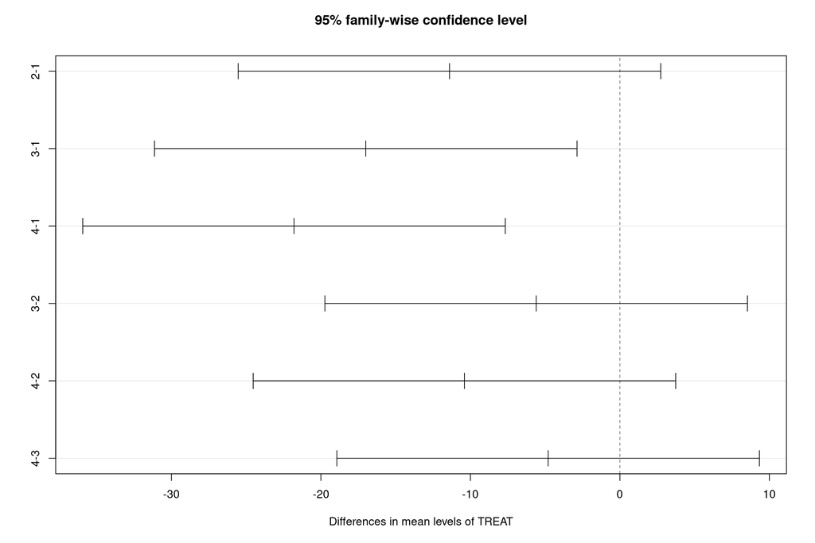

```r
plot(hsd)
```

```r
### Check ANOVA model assumptions

opt<- par(mfrow=c(2,2))
plot(aov1)
```

[output not shown]

```r
par(opt)

### Clean memory
detach(dades)
rm(dades)
```

## 2.2 Randomized block design

```r
regeneration<-c(34.98,41.22,36.94,39.97,40.89,46.69, 46.65, 41.90, 42.07, 49.42, 52.68, 42.91, 37.18, 45.85, 40.23, 39.20, 37.99, 41.99, 37.61, 40.45, 34.89, 50.15, 44.57, 43.29)
dades<-expand.grid(medium=1:4, Tx =1:6)
dades<-cbind(dades,regeneration)
dades$medium<-as.factor(dades$medium)
dades$Tx<-as.factor(dades$Tx)
write.csv2(dades, "dadesRBD.csv2", row.names=TRUE)
kableExtra::kable(dades)
```

| medium | Tx | regeneration |
| --- | --- | --- |
| 1 | 1 | 34.98 |
| 2 | 1 | 41.22 |
| 3 | 1 | 36.94 |
| 4 | 1 | 39.97 |
| 1 | 2 | 40.89 |
| 2 | 2 | 46.69 |
| 3 | 2 | 46.65 |
| 4 | 2 | 41.90 |
| 1 | 3 | 42.07 |
| 2 | 3 | 49.42 |
| 3 | 3 | 52.68 |
| 4 | 3 | 42.91 |
| 1 | 4 | 37.18 |
| 2 | 4 | 45.85 |
| 3 | 4 | 40.23 |
| 4 | 4 | 39.20 |
| 1 | 5 | 37.99 |
| 2 | 5 | 41.99 |
| 3 | 5 | 37.61 |
| 4 | 5 | 40.45 |
| 1 | 6 | 34.89 |
| 2 | 6 | 50.15 |
| 3 | 6 | 44.57 |
| 4 | 6 | 43.29 |

```r
attach(dades)
model.1<- regeneration ~ medium + Tx
aov.1<-aov (model.1, data=dades)
summary(aov.1)
```

```
##             Df Sum Sq Mean Sq F value  Pr(>F)
## medium       3  197.0   65.67   9.120 0.00112 **
## Tx           5  201.3   40.26   5.592 0.00419 **
## Residuals   15  108.0    7.20
## ---
## Signif. codes:  0 '***' 0.001 '**' 0.01 '*' 0.05 '.' 0.1 ' ' 1
```

```r
### If blocking had been ignored

model.0<- regeneration ~  Tx
aov.0<-aov (model.0, data=dades)
summary(aov.0)
```

```
##             Df Sum Sq Mean Sq F value Pr(>F)
## Tx           5  201.3   40.26   2.376 0.0802 .
## Residuals   18  305.0   16.95
## ---
## Signif. codes:  0 '***' 0.001 '**' 0.01 '*' 0.05 '.' 0.1 ' ' 1
```

```r
### Check ANOVA model assumptions

opt<- par(mfrow=c(2,2))
plot(aov1)
```

[output not shown]

```r
par(opt)

### Clean memory
detach(dades)
rm(dades)
```

## 2.3 Factorial design

```r
dades<-expand.grid(replica=1:5, tratamiento = c("Control", "Trat"),cepa=c("CD1", "CBA"))
WBC<-c( 3, 1.7, 1.5,2, 2.1, 1.9, 1.9, 3.5, 1.2, 2.3, 1.9, 2.6, 1.4, 1.6, 1.1, 0.4, 0.2, 0.1, 0.4, 0.3)
dades$cepa <-as.factor(dades$cepa)
dades$tratamiento <-as.factor(dades$tratamiento)
dades <- cbind(dades, WBC)
write.csv2(dades, "dadesFACTD.csv2", row.names=F)
kableExtra::kable(dades)
```

| replica | tratamiento | cepa | WBC |
| --- | --- | --- | --- |
| 1 | Control | CD1 | 3.0 |
| 2 | Control | CD1 | 1.7 |
| 3 | Control | CD1 | 1.5 |
| 4 | Control | CD1 | 2.0 |
| 5 | Control | CD1 | 2.1 |
| 1 | Trat | CD1 | 1.9 |
| 2 | Trat | CD1 | 1.9 |
| 3 | Trat | CD1 | 3.5 |
| 4 | Trat | CD1 | 1.2 |
| 5 | Trat | CD1 | 2.3 |
| 1 | Control | CBA | 1.9 |
| 2 | Control | CBA | 2.6 |
| 3 | Control | CBA | 1.4 |
| 4 | Control | CBA | 1.6 |
| 5 | Control | CBA | 1.1 |
| 1 | Trat | CBA | 0.4 |
| 2 | Trat | CBA | 0.2 |
| 3 | Trat | CBA | 0.1 |
| 4 | Trat | CBA | 0.4 |
| 5 | Trat | CBA | 0.3 |

```r
attach(dades)

model.1<- WBC ~ tratamiento + cepa # this model ignores interaction
aov.1<-aov (model.1, data=dades)
summary(aov.1)
```

```
##             Df Sum Sq Mean Sq F value  Pr(>F)
## tratamiento  1  2.244   2.244   4.466 0.04967 *
## cepa         1  6.160   6.160  12.257 0.00274 **
## Residuals   17  8.544   0.503
## ---
## Signif. codes:  0 '***' 0.001 '**' 0.01 '*' 0.05 '.' 0.1 ' ' 1
```

```r
model.2<- WBC ~ tratamiento + cepa + cepa:tratamiento
aov.2<-aov (model.2, data=dades)
summary(aov.2) # this shows that interaction had to be considered
```

```
##                  Df Sum Sq Mean Sq F value   Pr(>F)
## tratamiento       1  2.244   2.244   6.436 0.021978 *
## cepa              1  6.160   6.160  17.665 0.000674 ***
## tratamiento:cepa  1  2.965   2.965   8.500 0.010110 *
## Residuals        16  5.580   0.349
## ---
## Signif. codes:  0 '***' 0.001 '**' 0.01 '*' 0.05 '.' 0.1 ' ' 1
```

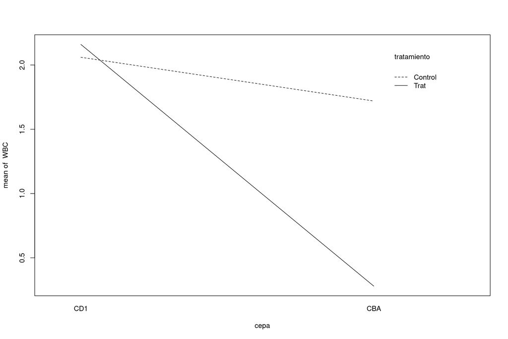

```r
interaction.plot(cepa, tratamiento, WBC)
```

```r
### Check ANOVA model assumptions
opt<- par(mfrow=c(2,2)); plot(aov1); par(opt)
```

[output not shown]

```r
### Clean memory
detach(dades); rm(dades)
```